# Project 1

Clay Curry

2020-09-28

# 1 Introduction to the data

## 1.1 Data and Variables (see MS pg. 77,125)

Rigorous code evaluation in software development is critical for launching programs that with as little bugs and vulnerabilities as possible. As computer systems evolve, however, software engineers face the daunting task of having to retest their code for an infinitely growing number of additional vulnerabilities that new technology brings. In many ways, the cost of supporting rigorous code evaluations can grow to be much larger than the rewards of the software itself. When software engineers are hired to assess code, it is therefore necessary to devise systematic methods of triaging code and perform statistical analysis on their efficacy.

Certain guidelines were implemented by researchers to test various methods of triaging code. In the form of algorithms, these triaging methods were applied to 498 modules of code. The SWDEFECTS file contains a variable that corresponds to each method. When the method predicts a defect, the corresponding variable’s value is “yes”, and “no” otherwise. The accuracy of each method was determined by a complete evaluation of the code. The methods were evalued by computing several probability measures, called accuracy, detection rate, false alarm rate, and precision.

## 1.2 Summary Table

TABLE SIA3.2 found on page 125.

Summary Table for Evaluating Defect Prediction Algorithms

[output not shown]

$$\text{Accuracy: } \ \ \ P(\text{Algorithm is correct}) =\frac{(a + d)}{(a + b + c + d)}$$

$$\text{Detection Rate: } \ \ \ P(\text{predict defect | module has defect}) =\frac{d}{(b + d)}$$

$$\text{False alarm Rate: } \ \ \ P(\text{predict defect | module has no defect}) =\frac{c}{(a + c)}$$

$$\text{Precision: } \ \ \ P(\text{module has defect | predict defect}) =\frac{d}{(c + d)}$$

# 2 R functions

Using the above definitions make R functions that will create the required probabilities, please remove `eval=FALSE` when creating the functions :

```r
acc=function(a,b,c,d)
{
  (a+d)/(a+b+c+d)
}
```

```r
detect=function(b,d)
{
  d/(b+d)
}
```

```r
falarm=function(a,c)
{
  c/(a+c)
}
```

```r
prec=function(c,d)
{
  d/(c+d)
}
```

# 3 Create the tables in Figure SIA3.1

The tables do not have to be formatted exactly as those in the book. Have the functions produce a suitable barplot also.

As a guide and help – see code below

```r
tab1 = with(SWDEFECTS, table(PREDICT_LOC, defect))
tab2 = with(SWDEFECTS, table(PREDICT_VG, defect))
tab3 = with(SWDEFECTS, table(PREDICT_EVG, defect))
tab4 = with(SWDEFECTS, table(PREDICT_IVG, defect))

addmargins(tab1)
```

```
##            defect
## PREDICT_LOC FALSE TRUE Sum
##         no    400   29 429
##         yes    49   20  69
##         Sum   449   49 498
```

```r
addmargins(tab2)
```

```
##           defect
## PREDICT_VG FALSE TRUE Sum
##        no    397   35 432
##        yes    52   14  66
##        Sum   449   49 498
```

```r
addmargins(tab3)
```

```
##            defect
## PREDICT_EVG FALSE TRUE Sum
##         no    441   47 488
##         yes     8    2  10
##         Sum   449   49 498
```

```r
addmargins(tab4)
```

```
##            defect
## PREDICT_IVG FALSE TRUE Sum
##         no    422   38 460
##         yes    27   11  38
##         Sum   449   49 498
```

**Probability Measures for Evaluating Defect Prediction Algorithms**

```r
head(SWDEFECTS)
```

|  | Mloc | Mvg | Mevg | Mivg | Hn | Hvol | Hpgmlen | Hdiff | Hintell | Heffort | Hb | Htime | Hloc | Hcomm | Hblank | loc.comm | uniOp | uniOpnd | totOp | totOpnd | brnchcnt | defect | PREDICT_VG | PREDICT_EVG | PREDICT_IVG | PREDICT_LOC |
| --- | --- | --- | --- | --- | --- | --- | --- | --- | --- | --- | --- | --- | --- | --- | --- | --- | --- | --- | --- | --- | --- | --- | --- | --- | --- | --- |
| 1 | 1.1 | 1.4 | 1.4 | 1.4 | 1.3 | 1.3 | 1.30 | 1.30 | 1.30 | 1 | 1.30 | 1 | 2 | 2 | 2 | 2 | 1.2 | 1.2 | 1.2 | 1.2 | 1.4 | FALSE | no | no | no | no |
| 2 | 1.0 | 1.0 | 1.0 | 1.0 | 1.0 | 1.0 | 1.00 | 1.00 | 1.00 | 1 | 1.00 | 1 | 1 | 1 | 1 | 1 | 1.0 | 1.0 | 1.0 | 1.0 | 1.0 | TRUE | no | no | no | no |
| 3 | 24.0 | 5.0 | 1.0 | 3.0 | 63.0 | 309.1 | 0.11 | 9.50 | 32.54 | 2937 | 0.10 | 163 | 1 | 0 | 6 | 0 | 15.0 | 15.0 | 44.0 | 19.0 | 9.0 | FALSE | no | no | no | no |
| 4 | 20.0 | 4.0 | 4.0 | 2.0 | 47.0 | 215.5 | 0.06 | 16.00 | 13.47 | 3448 | 0.07 | 192 | 0 | 0 | 3 | 0 | 16.0 | 8.0 | 31.0 | 16.0 | 7.0 | FALSE | no | no | no | no |
| 5 | 24.0 | 6.0 | 6.0 | 2.0 | 72.0 | 346.1 | 0.06 | 17.33 | 19.97 | 6000 | 0.12 | 333 | 0 | 0 | 3 | 0 | 16.0 | 12.0 | 46.0 | 26.0 | 11.0 | FALSE | no | no | no | no |
| 6 | 24.0 | 6.0 | 6.0 | 2.0 | 72.0 | 346.1 | 0.06 | 17.33 | 19.97 | 6000 | 0.12 | 333 | 0 | 0 | 3 | 0 | 16.0 | 12.0 | 46.0 | 26.0 | 11.0 | FALSE | no | no | no | no |

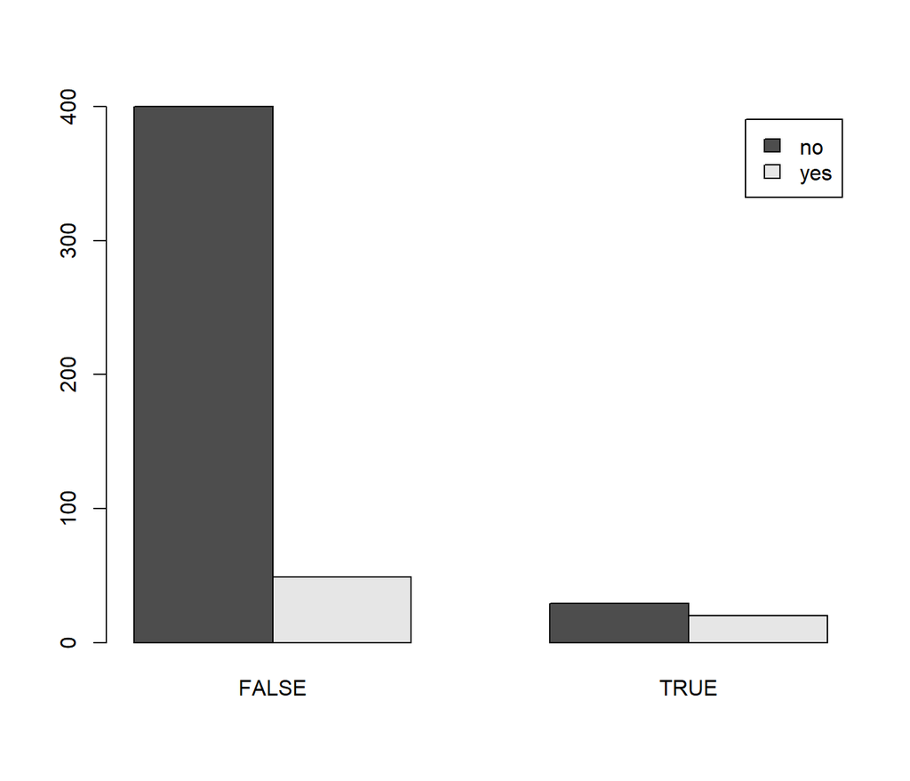

```r
tab=with(SWDEFECTS, table(PREDICT_LOC,defect))
barplot(tab, beside=TRUE, leg=TRUE)
```

```r
tab2=addmargins(tab)
tab2
```

```
##            defect
## PREDICT_LOC FALSE TRUE Sum
##         no    400   29 429
##         yes    49   20  69
##         Sum   449   49 498
```

# 4 Create the corrected table on page 127 (there are mistakes in it), TABLE SIA3.3

```r
genRow = function(tab)
{
  df = data.frame(tab)
  a = df[df[1]=="no" & df[2]=="FALSE",3]
  b = df[df[1]=="no" & df[2]=="TRUE",3]
  c = df[df[1]=="yes" & df[2]=="FALSE",3]
  d = df[df[1]=="yes" & df[2]=="TRUE",3]
  AC = (a+d)/(a+b+c+d)
  DR = d/(b+d)
  FAR = c/(a+c)
  PR = d/(c+d)

  c(AC,DR, FAR, PR)
}
mybar = function(tab, acc = 3)
{
  barplot(tab, col = 1:4, beside = TRUE, legend.text = c("Lines of Code", "Cyclomatic Complexity", "Essential Complexity", "Design Complexity"), main = "Probability Measures for Evaluating Defect Predition Algorithms")

  tab = round(tab, acc)
  df = data.frame(tab, row.names = c("Lines of Code", "Cyclomatic Complexity", "Essential Complexity", "Design Complexity"))
  colnames(df) = c("Accuracy", "Detection Rate", "False Alarm Rate", "Precision")
  list(df)
}

mat = matrix(c(genRow(tab1), genRow(tab2), genRow(tab3), genRow(tab4)), nrow = 4, ncol = 4, byrow = TRUE)

mat
```

```
##           [,1]       [,2]       [,3]      [,4]
## [1,] 0.8433735 0.40816327 0.10913140 0.2898551
## [2,] 0.8433735 0.40816327 0.10913140 0.2898551
## [3,] 0.8895582 0.04081633 0.01781737 0.2000000
## [4,] 0.8694779 0.22448980 0.06013363 0.2894737
```

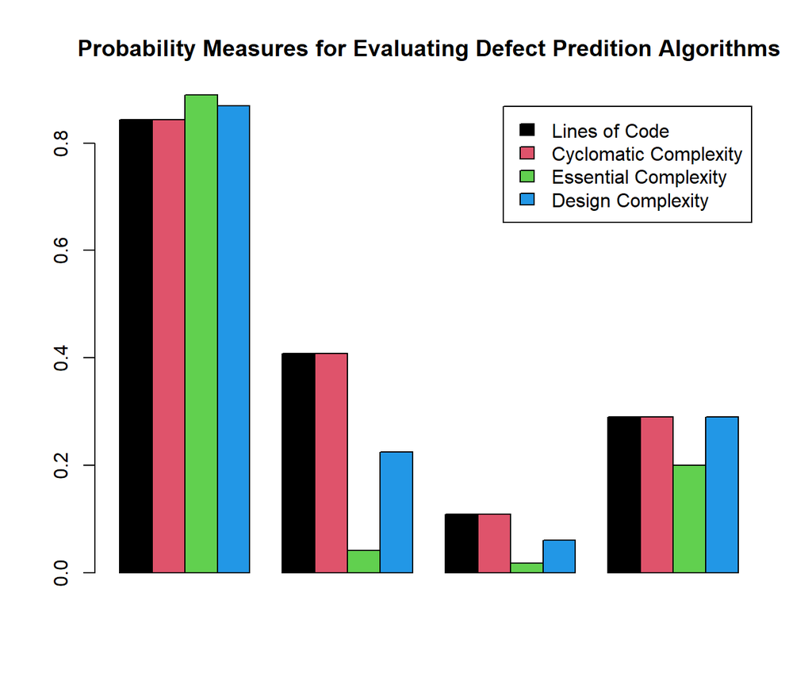

[output not shown]

```r
mybar(mat)
```